# Optimal Treatment Analysis

## Outcome Variable

**Outcome Variable:** whz

## Predictor Variables

**Intervention Variable:** perdiar24

**Adjustment Set:**

- arm
- sex
- meducyrs
- feducyrs
- hhwealth_quart
- hfoodsec
- vagbrth
- hdlvry
- W_birthwt
- W_birthlen
- single
- W_nrooms
- month
- brthmon
- impfloor
- impsan
- safeh20
- delta_meducyrs
- delta_feducyrs
- delta_hhwealth_quart
- delta_hfoodsec
- delta_vagbrth
- delta_hdlvry
- delta_W_birthwt
- delta_W_birthlen
- delta_single
- delta_W_nrooms
- delta_month
- delta_brthmon
- delta_impfloor
- delta_impsan
- delta_safeh20

## Stratifying Variables

The analysis was stratified on these variable(s):

- agecat
- studyid
- country

## Data Summary

| agecat | studyid | country | perdiar24 | n_cell | n |
| --- | --- | --- | --- | --- | --- |
| Birth | CMIN | BANGLADESH | 0% | 6 | 19 |
| Birth | CMIN | BANGLADESH | (0%, 5%] | 3 | 19 |
| Birth | CMIN | BANGLADESH | >5% | 10 | 19 |
| Birth | CONTENT | PERU | 0% | 0 | 2 |
| Birth | CONTENT | PERU | (0%, 5%] | 1 | 2 |
| Birth | CONTENT | PERU | >5% | 1 | 2 |
| Birth | EE | PAKISTAN | 0% | 115 | 177 |
| Birth | EE | PAKISTAN | (0%, 5%] | 62 | 177 |
| Birth | EE | PAKISTAN | >5% | 0 | 177 |
| Birth | JiVitA-4 | BANGLADESH | 0% | 61 | 2396 |
| Birth | JiVitA-4 | BANGLADESH | (0%, 5%] | 2091 | 2396 |
| Birth | JiVitA-4 | BANGLADESH | >5% | 244 | 2396 |
| Birth | MAL-ED | BANGLADESH | 0% | 14 | 215 |
| Birth | MAL-ED | BANGLADESH | (0%, 5%] | 127 | 215 |
| Birth | MAL-ED | BANGLADESH | >5% | 74 | 215 |
| Birth | MAL-ED | BRAZIL | 0% | 34 | 62 |
| Birth | MAL-ED | BRAZIL | (0%, 5%] | 26 | 62 |
| Birth | MAL-ED | BRAZIL | >5% | 2 | 62 |
| Birth | MAL-ED | INDIA | 0% | 5 | 45 |
| Birth | MAL-ED | INDIA | (0%, 5%] | 31 | 45 |
| Birth | MAL-ED | INDIA | >5% | 9 | 45 |
| Birth | MAL-ED | NEPAL | 0% | 2 | 26 |
| Birth | MAL-ED | NEPAL | (0%, 5%] | 19 | 26 |
| Birth | MAL-ED | NEPAL | >5% | 5 | 26 |
| Birth | MAL-ED | PERU | 0% | 21 | 228 |
| Birth | MAL-ED | PERU | (0%, 5%] | 87 | 228 |
| Birth | MAL-ED | PERU | >5% | 120 | 228 |
| Birth | MAL-ED | SOUTH AFRICA | 0% | 42 | 112 |
| Birth | MAL-ED | SOUTH AFRICA | (0%, 5%] | 69 | 112 |
| Birth | MAL-ED | SOUTH AFRICA | >5% | 1 | 112 |

[output cut: 102 more lines]

The following strata were considered:

- agecat: 24 months, studyid: CMIN, country: BANGLADESH
- agecat: 24 months, studyid: CONTENT, country: PERU
- agecat: 24 months, studyid: EE, country: PAKISTAN
- agecat: 24 months, studyid: JiVitA-4, country: BANGLADESH
- agecat: 24 months, studyid: MAL-ED, country: BANGLADESH
- agecat: 24 months, studyid: MAL-ED, country: BRAZIL
- agecat: 24 months, studyid: MAL-ED, country: INDIA
- agecat: 24 months, studyid: MAL-ED, country: NEPAL
- agecat: 24 months, studyid: MAL-ED, country: PERU
- agecat: 24 months, studyid: MAL-ED, country: SOUTH AFRICA
- agecat: 24 months, studyid: MAL-ED, country: TANZANIA, UNITED REPUBLIC OF
- agecat: 24 months, studyid: NIH-Birth, country: BANGLADESH
- agecat: 24 months, studyid: NIH-Crypto, country: BANGLADESH
- agecat: 24 months, studyid: PROVIDE, country: BANGLADESH
- agecat: 6 months, studyid: CMIN, country: BANGLADESH
- agecat: 6 months, studyid: CONTENT, country: PERU
- agecat: 6 months, studyid: EE, country: PAKISTAN
- agecat: 6 months, studyid: Guatemala BSC, country: GUATEMALA
- agecat: 6 months, studyid: JiVitA-4, country: BANGLADESH
- agecat: 6 months, studyid: MAL-ED, country: BANGLADESH
- agecat: 6 months, studyid: MAL-ED, country: BRAZIL
- agecat: 6 months, studyid: MAL-ED, country: INDIA
- agecat: 6 months, studyid: MAL-ED, country: NEPAL
- agecat: 6 months, studyid: MAL-ED, country: PERU
- agecat: 6 months, studyid: MAL-ED, country: SOUTH AFRICA
- agecat: 6 months, studyid: MAL-ED, country: TANZANIA, UNITED REPUBLIC OF
- agecat: 6 months, studyid: NIH-Birth, country: BANGLADESH
- agecat: 6 months, studyid: NIH-Crypto, country: BANGLADESH
- agecat: 6 months, studyid: PROVIDE, country: BANGLADESH
- agecat: 6 months, studyid: SAS-FoodSuppl, country: INDIA
- agecat: Birth, studyid: CMIN, country: BANGLADESH
- agecat: Birth, studyid: CONTENT, country: PERU
- agecat: Birth, studyid: EE, country: PAKISTAN
- agecat: Birth, studyid: JiVitA-4, country: BANGLADESH
- agecat: Birth, studyid: MAL-ED, country: BANGLADESH
- agecat: Birth, studyid: MAL-ED, country: BRAZIL
- agecat: Birth, studyid: MAL-ED, country: INDIA
- agecat: Birth, studyid: MAL-ED, country: NEPAL
- agecat: Birth, studyid: MAL-ED, country: PERU
- agecat: Birth, studyid: MAL-ED, country: SOUTH AFRICA
- agecat: Birth, studyid: MAL-ED, country: TANZANIA, UNITED REPUBLIC OF
- agecat: Birth, studyid: NIH-Birth, country: BANGLADESH
- agecat: Birth, studyid: NIH-Crypto, country: BANGLADESH
- agecat: Birth, studyid: PROVIDE, country: BANGLADESH

### Dropped Strata

Some strata were dropped due to rare outcomes:

- agecat: Birth, studyid: CMIN, country: BANGLADESH
- agecat: Birth, studyid: CONTENT, country: PERU
- agecat: Birth, studyid: EE, country: PAKISTAN
- agecat: Birth, studyid: MAL-ED, country: BRAZIL
- agecat: Birth, studyid: MAL-ED, country: NEPAL
- agecat: Birth, studyid: MAL-ED, country: SOUTH AFRICA
- agecat: 6 months, studyid: CMIN, country: BANGLADESH
- agecat: 6 months, studyid: EE, country: PAKISTAN
- agecat: 6 months, studyid: MAL-ED, country: BRAZIL
- agecat: 6 months, studyid: MAL-ED, country: INDIA
- agecat: 6 months, studyid: MAL-ED, country: SOUTH AFRICA
- agecat: 24 months, studyid: CMIN, country: BANGLADESH
- agecat: 24 months, studyid: CONTENT, country: PERU
- agecat: 24 months, studyid: EE, country: PAKISTAN
- agecat: 24 months, studyid: MAL-ED, country: BRAZIL
- agecat: 24 months, studyid: MAL-ED, country: INDIA
- agecat: 24 months, studyid: MAL-ED, country: PERU
- agecat: 24 months, studyid: MAL-ED, country: SOUTH AFRICA

## Methods Detail

We’re interested in the causal parameters $E[Y_a]$ for all values of $a \in \mathcal{A}$. These parameters represent the mean outcome if, possibly contrary to fact, we intervened to set all units to have $A=a$. Under the randomization and positivity assumptions, these are identified by the statistical parameters $\psi_a=E_W[E_{Y|A,W}(Y|A=a,W)]$. In addition, we’re interested in the mean of $Y$, $E[Y]$ under no intervention (the observed mean). We will estimate these parameters by using SuperLearner to fit the relevant likelihood factors – $E_{Y|A,W}(Y|A=a,W)$ and $p(A=a|W)$, and then updating our likelihood fit using a joint TMLE.

For unadjusted analyses ($W=\{\}$), initial likelihoods were estimated using Lrnr_glm to estimate the simple $E(Y|A)$ and Lrnr_mean to estimate $p(A)$. For adjusted analyses, a small library containing Lrnr_glmnet, Lrnr_xgboost, and Lrnr_mean was used.

Having estimated these parameters, we will then use the delta method to estimate relative risks and attributable risks relative to a prespecified baseline level of $A$.

# Results Detail

## Results Plots

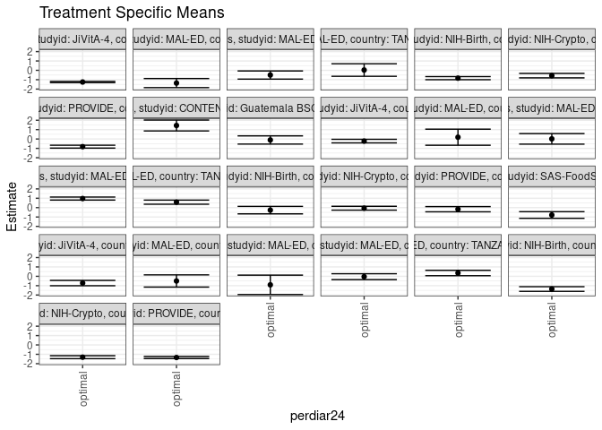

## Results Table

### Parameter: TSM

| agecat | studyid | country | intervention_level | baseline_level | estimate | ci_lower | ci_upper |
| --- | --- | --- | --- | --- | --- | --- | --- |
| Birth | JiVitA-4 | BANGLADESH | optimal | observed | -0.7230599 | -1.0083316 | -0.4377883 |
| Birth | MAL-ED | BANGLADESH | optimal | observed | -0.5000260 | -1.1514127 | 0.1513607 |
| Birth | MAL-ED | INDIA | optimal | observed | -0.9112554 | -1.9446838 | 0.1221730 |
| Birth | MAL-ED | PERU | optimal | observed | -0.0410648 | -0.3555317 | 0.2734021 |
| Birth | MAL-ED | TANZANIA, UNITED REPUBLIC OF | optimal | observed | 0.3501128 | 0.0623055 | 0.6379201 |
| Birth | NIH-Birth | BANGLADESH | optimal | observed | -1.3590091 | -1.6092994 | -1.1087188 |
| Birth | NIH-Crypto | BANGLADESH | optimal | observed | -1.3068331 | -1.4655917 | -1.1480745 |
| Birth | PROVIDE | BANGLADESH | optimal | observed | -1.3402154 | -1.4553868 | -1.2250440 |
| 6 months | CONTENT | PERU | optimal | observed | 1.4406008 | 0.8598033 | 2.0213982 |
| 6 months | Guatemala BSC | GUATEMALA | optimal | observed | -0.1043363 | -0.5410511 | 0.3323785 |
| 6 months | JiVitA-4 | BANGLADESH | optimal | observed | -0.2258950 | -0.4166177 | -0.0351723 |
| 6 months | MAL-ED | BANGLADESH | optimal | observed | 0.1897329 | -0.6668452 | 1.0463110 |
| 6 months | MAL-ED | NEPAL | optimal | observed | 0.0142507 | -0.5475021 | 0.5760034 |
| 6 months | MAL-ED | PERU | optimal | observed | 0.9690393 | 0.8086333 | 1.1294454 |
| 6 months | MAL-ED | TANZANIA, UNITED REPUBLIC OF | optimal | observed | 0.5861250 | 0.3666619 | 0.8055881 |
| 6 months | NIH-Birth | BANGLADESH | optimal | observed | -0.2644022 | -0.6648227 | 0.1360184 |
| 6 months | NIH-Crypto | BANGLADESH | optimal | observed | -0.0603184 | -0.2660371 | 0.1454004 |
| 6 months | PROVIDE | BANGLADESH | optimal | observed | -0.1660053 | -0.4460025 | 0.1139919 |
| 6 months | SAS-FoodSuppl | INDIA | optimal | observed | -0.7857493 | -1.1394618 | -0.4320369 |
| 24 months | JiVitA-4 | BANGLADESH | optimal | observed | -1.2462493 | -1.3145137 | -1.1779850 |
| 24 months | MAL-ED | BANGLADESH | optimal | observed | -1.3612157 | -1.8480197 | -0.8744117 |
| 24 months | MAL-ED | NEPAL | optimal | observed | -0.5009650 | -0.9365755 | -0.0653545 |
| 24 months | MAL-ED | TANZANIA, UNITED REPUBLIC OF | optimal | observed | 0.0345739 | -0.6334098 | 0.7025577 |
| 24 months | NIH-Birth | BANGLADESH | optimal | observed | -0.8337612 | -0.9985418 | -0.6689807 |
| 24 months | NIH-Crypto | BANGLADESH | optimal | observed | -0.5653039 | -0.8034332 | -0.3271746 |
| 24 months | PROVIDE | BANGLADESH | optimal | observed | -0.8185688 | -0.9734213 | -0.6637163 |

### Parameter: E(Y)

| agecat | studyid | country | intervention_level | baseline_level | estimate | ci_lower | ci_upper |
| --- | --- | --- | --- | --- | --- | --- | --- |
| Birth | JiVitA-4 | BANGLADESH | observed | observed | -0.6886269 | -0.7410452 | -0.6362086 |
| Birth | MAL-ED | BANGLADESH | observed | observed | -0.9418605 | -1.0869834 | -0.7967375 |
| Birth | MAL-ED | INDIA | observed | observed | -0.9324444 | -1.2067907 | -0.6580982 |
| Birth | MAL-ED | PERU | observed | observed | -0.0520175 | -0.1725298 | 0.0684947 |
| Birth | MAL-ED | TANZANIA, UNITED REPUBLIC OF | observed | observed | 0.7624348 | 0.5710709 | 0.9537986 |
| Birth | NIH-Birth | BANGLADESH | observed | observed | -1.3525437 | -1.4473932 | -1.2576942 |
| Birth | NIH-Crypto | BANGLADESH | observed | observed | -1.2441513 | -1.3281130 | -1.1601897 |
| Birth | PROVIDE | BANGLADESH | observed | observed | -1.2984586 | -1.3752758 | -1.2216415 |
| 6 months | CONTENT | PERU | observed | observed | 1.0644279 | 0.9468682 | 1.1819876 |
| 6 months | Guatemala BSC | GUATEMALA | observed | observed | -0.0840134 | -0.1945572 | 0.0265305 |
| 6 months | JiVitA-4 | BANGLADESH | observed | observed | -0.3898055 | -0.4270507 | -0.3525603 |
| 6 months | MAL-ED | BANGLADESH | observed | observed | -0.1376763 | -0.2664642 | -0.0088885 |
| 6 months | MAL-ED | NEPAL | observed | observed | 0.1104308 | -0.0208643 | 0.2417259 |
| 6 months | MAL-ED | PERU | observed | observed | 1.0528816 | 0.9313005 | 1.1744626 |
| 6 months | MAL-ED | TANZANIA, UNITED REPUBLIC OF | observed | observed | 0.5362213 | 0.4049390 | 0.6675036 |
| 6 months | NIH-Birth | BANGLADESH | observed | observed | -0.4474038 | -0.5378167 | -0.3569909 |
| 6 months | NIH-Crypto | BANGLADESH | observed | observed | 0.0297622 | -0.0491685 | 0.1086930 |
| 6 months | PROVIDE | BANGLADESH | observed | observed | -0.1990907 | -0.2817968 | -0.1163845 |
| 6 months | SAS-FoodSuppl | INDIA | observed | observed | -1.0121579 | -1.1280429 | -0.8962729 |
| 24 months | JiVitA-4 | BANGLADESH | observed | observed | -1.2231088 | -1.2549632 | -1.1912543 |
| 24 months | MAL-ED | BANGLADESH | observed | observed | -0.8192925 | -0.9412667 | -0.6973182 |
| 24 months | MAL-ED | NEPAL | observed | observed | -0.3749123 | -0.4886073 | -0.2612173 |
| 24 months | MAL-ED | TANZANIA, UNITED REPUBLIC OF | observed | observed | 0.0547975 | -0.0703378 | 0.1799328 |
| 24 months | NIH-Birth | BANGLADESH | observed | observed | -0.9115790 | -1.0095022 | -0.8136559 |
| 24 months | NIH-Crypto | BANGLADESH | observed | observed | -0.6103502 | -0.7050157 | -0.5156847 |
| 24 months | PROVIDE | BANGLADESH | observed | observed | -0.8928670 | -0.9755153 | -0.8102187 |

### Parameter: PAR

| agecat | studyid | country | intervention_level | baseline_level | estimate | ci_lower | ci_upper |
| --- | --- | --- | --- | --- | --- | --- | --- |
| Birth | JiVitA-4 | BANGLADESH | optimal | observed | 0.0344331 | -0.2406174 | 0.3094835 |
| Birth | MAL-ED | BANGLADESH | optimal | observed | -0.4418345 | -1.0725392 | 0.1888703 |
| Birth | MAL-ED | INDIA | optimal | observed | -0.0211891 | -0.9433186 | 0.9009404 |
| Birth | MAL-ED | PERU | optimal | observed | -0.0109528 | -0.2990965 | 0.2771910 |
| Birth | MAL-ED | TANZANIA, UNITED REPUBLIC OF | optimal | observed | 0.4123220 | 0.1247912 | 0.6998528 |
| Birth | NIH-Birth | BANGLADESH | optimal | observed | 0.0064654 | -0.2386354 | 0.2515662 |
| Birth | NIH-Crypto | BANGLADESH | optimal | observed | 0.0626818 | -0.0687722 | 0.1941357 |
| Birth | PROVIDE | BANGLADESH | optimal | observed | 0.0417567 | -0.0443200 | 0.1278335 |
| 6 months | CONTENT | PERU | optimal | observed | -0.3761729 | -0.9558461 | 0.2035004 |
| 6 months | Guatemala BSC | GUATEMALA | optimal | observed | 0.0203229 | -0.3877931 | 0.4284390 |
| 6 months | JiVitA-4 | BANGLADESH | optimal | observed | -0.1639105 | -0.3499475 | 0.0221266 |
| 6 months | MAL-ED | BANGLADESH | optimal | observed | -0.3274092 | -1.1741460 | 0.5193275 |
| 6 months | MAL-ED | NEPAL | optimal | observed | 0.0961801 | -0.4281782 | 0.6205384 |
| 6 months | MAL-ED | PERU | optimal | observed | 0.0838422 | -0.0224931 | 0.1901775 |
| 6 months | MAL-ED | TANZANIA, UNITED REPUBLIC OF | optimal | observed | -0.0499037 | -0.2552029 | 0.1553955 |
| 6 months | NIH-Birth | BANGLADESH | optimal | observed | -0.1830016 | -0.5835096 | 0.2175064 |
| 6 months | NIH-Crypto | BANGLADESH | optimal | observed | 0.0900806 | -0.1000819 | 0.2802430 |
| 6 months | PROVIDE | BANGLADESH | optimal | observed | -0.0330854 | -0.3068744 | 0.2407037 |
| 6 months | SAS-FoodSuppl | INDIA | optimal | observed | -0.2264086 | -0.5590492 | 0.1062321 |
| 24 months | JiVitA-4 | BANGLADESH | optimal | observed | 0.0231406 | -0.0348624 | 0.0811436 |
| 24 months | MAL-ED | BANGLADESH | optimal | observed | 0.5419232 | 0.0523238 | 1.0315227 |
| 24 months | MAL-ED | NEPAL | optimal | observed | 0.1260528 | -0.2994844 | 0.5515899 |
| 24 months | MAL-ED | TANZANIA, UNITED REPUBLIC OF | optimal | observed | 0.0202236 | -0.6422557 | 0.6827028 |
| 24 months | NIH-Birth | BANGLADESH | optimal | observed | -0.0778178 | -0.2138081 | 0.0581724 |
| 24 months | NIH-Crypto | BANGLADESH | optimal | observed | -0.0450463 | -0.2533043 | 0.1632117 |
| 24 months | PROVIDE | BANGLADESH | optimal | observed | -0.0742982 | -0.2026737 | 0.0540773 |